# How Do UN Speeches Reflect Global Priorities and Political Sentiment?

Text Analysis Project Showcase · November 3, 2026

Author

Ali Abdulmalek · POLS 4130 · Fall 2026

## Research Question

What themes appear most frequently in United Nations General Debate speeches from 2004 to 2015, and how does sentiment vary across these themes?

## Data

The project examines the United Nations General Debate corpus covering **2004–2015**.

- Original dataset: **5,175 records**
- Documents retained after removing unusable text: **3,149**
- Topic-modeling documents: **2,297**
- Unit of analysis: an individual text record

The analysis combines word frequency, dictionary-based sentiment, and topic modeling to investigate recurring patterns in UN speeches.

## Methods

### Word Frequency

Speeches were divided into individual words, which were counted and visualized using a frequency bar chart and word cloud.

### Sentiment Analysis

The **Bing Liu dictionary** assigns positive words +1 and negative words -1.

Document sentiment was calculated by summing matched dictionary values.

A separate analysis compared basic sentiment with a simple two-word negation adjustment.

Target sentiment examined dictionary words within four words of **security** and **development**.

### Topic Modeling

A **three-topic Latent Dirichlet Allocation (LDA)** model was fitted using the VEM method.

The reduced document-term matrix included:

- 2,297 documents
- 10,770 unique terms
- Word-document combinations occurring at least twice

Topics were interpreted using their most probable words. Topic labels remain provisional because several words overlap.

## Key Limitations

**Sentiment:** Dictionary scores may miss sarcasm, diplomatic context, quotations, and complicated negation. Longer speeches may accumulate larger scores.

**Topic modeling:** Filtering excludes some documents and words. Similar terms appear across topics, making precise labels difficult.

**Interpretation:** These methods measure patterns in language, not countries’ actual policy positions.

## Word Frequency

Frequently occurring words reflect recurring international concerns and institutional language.

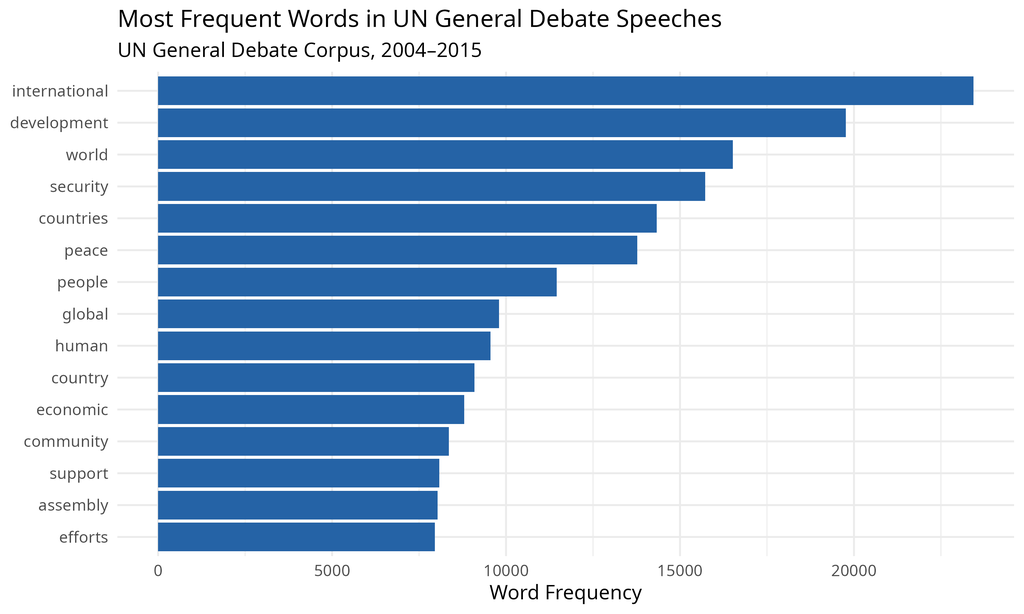

### Word Cloud

[figure not shown]

## Sentiment Findings

### Basic vs. Negation-Adjusted

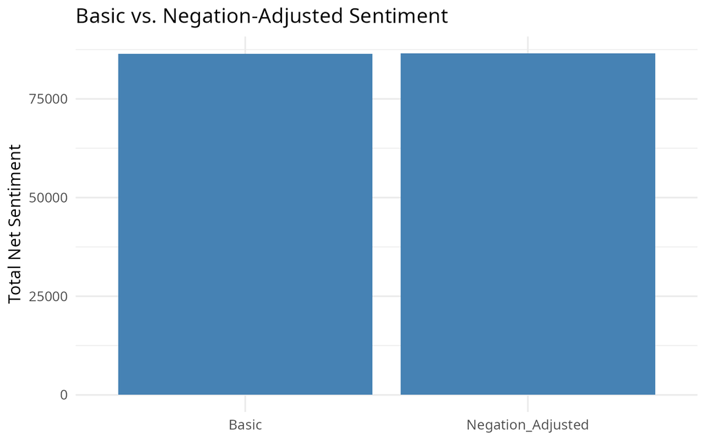

The overall scores are very similar. The simple negation adjustment has little effect on the aggregate result, although individual passages may be misclassified.

### Target Sentiment

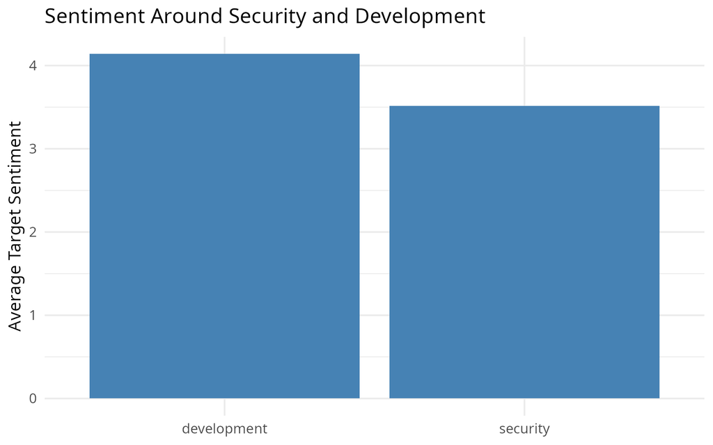

Development has a higher average dictionary sentiment than security.

This reflects nearby language rather than approval or disapproval of either issue.

## Topic Modeling Findings

The model identifies three recurring themes.

### Topic 1: Security and Development

**Keywords:** nations, united, development, international, security, global.

### Topic 2: Peace and Cooperation

**Keywords:** united, international, nations, peace, world, people.

### Topic 3: Global Development

**Keywords:** international, countries, world, development, nations, united.

### Top Words by Topic

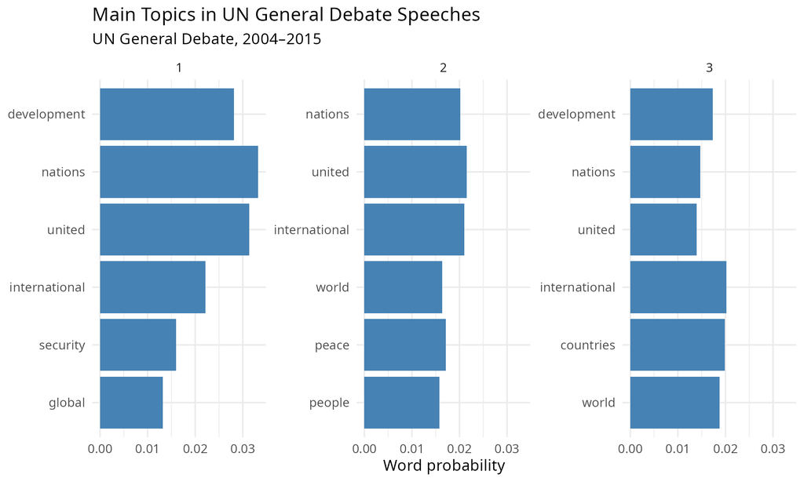

### Topic Proportions

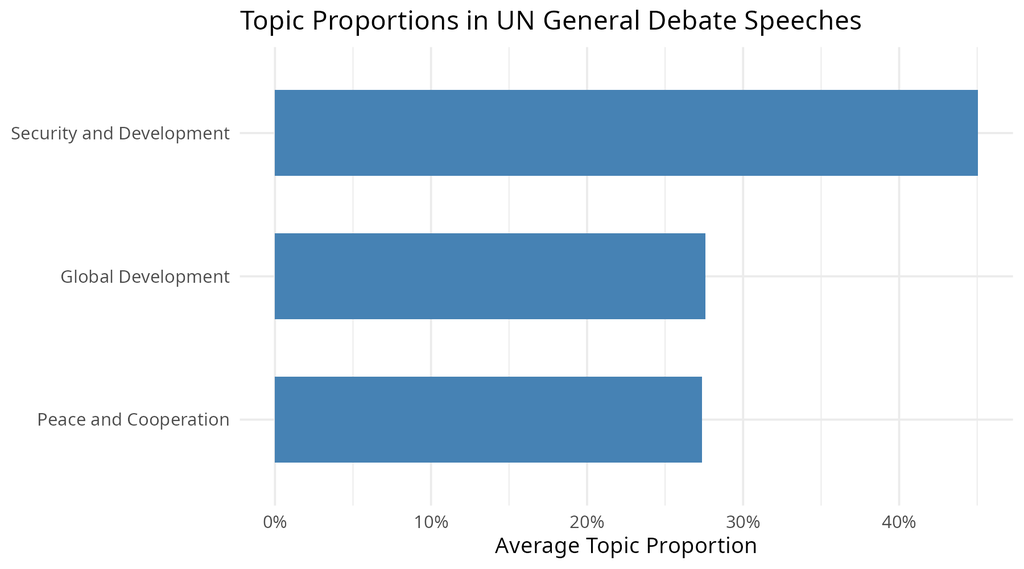

Security and Development has the largest estimated average share, approximately **45%**.

These figures represent estimated topic proportions, not exclusive document counts.

### Sentiment by Topic

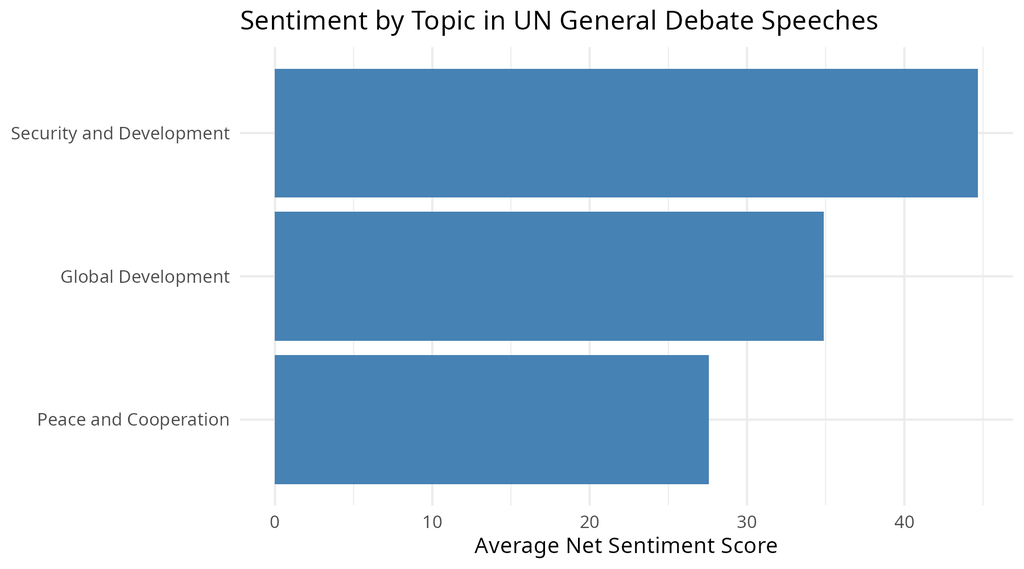

Security and Development also has the highest average net dictionary sentiment score among the three topic groups.

### Example Documents

The model identified these high-weight examples:

| Topic | Document ID |
| --- | --- |
| Security and Development | 3109 |
| Peace and Cooperation | 2093 |
| Global Development | 1829 |

The document IDs have been identified, but their original texts still need final verification before they can support the topic labels.

## Interpretation and Conclusion

The analysis shows recurring language concerning **development, international cooperation, security, and peace** in UN General Debate texts from 2004–2015.

The word-frequency and topic-modeling results highlight similar themes, although the topic labels overlap. Sentiment analysis suggests generally positive dictionary scores, with higher average sentiment around development than security. Security and Development also has the highest average sentiment among the three modeled topic groups.

Combining these methods offers multiple perspectives on the speeches. However, dictionary scores and topic proportions identify patterns in wording rather than directly measuring government positions or policy commitments.

**Sources:** United Nations General Debate corpus, 2004–2015, supplied project dataset; Bing Liu sentiment dictionary, supplied project dictionary.

**Software:** R, tidytext, dplyr, ggplot2, topicmodels, Quarto.

**Researcher:** Ali Abdulmalek, Loyola Marymount University.